# finalCodeandTechnicalAnalysis

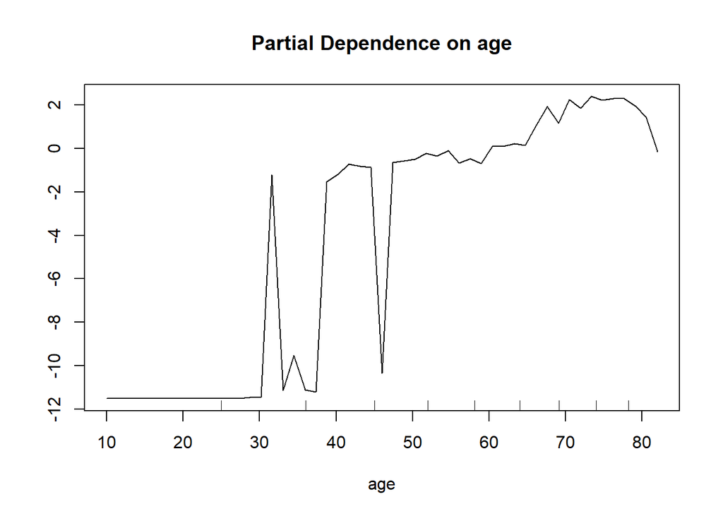

```r
partialPlot(rf3, afterSMOTE, age, "1")
```

We plotted a partial plot of dependence of age on getting a stroke.  
There are a few differences between the two plots, but overall they both are showing the same thing that higher age people tend to be more prone to stroke.

###ROC curve beforeSMOTE dataset

```r
library(pROC)
rf_predictionBS <- predict(rfBS3, test, type = "prob")
ROC_rfBS <- roc(test$stroke, rf_predictionBS[,2])
```

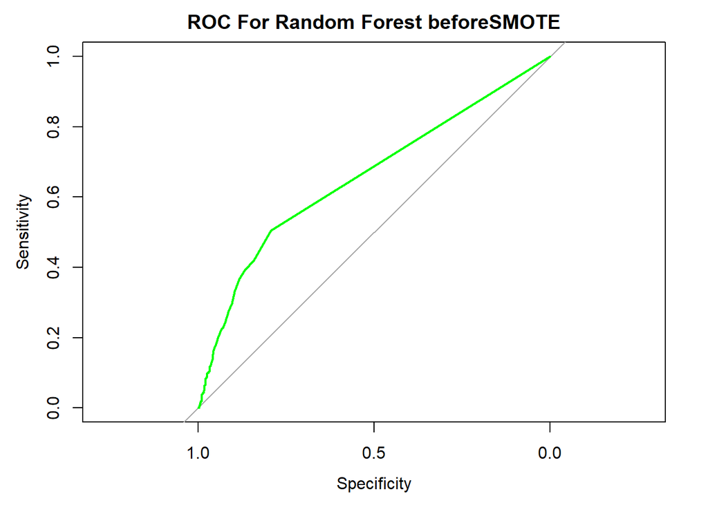

```r
ROC_rf_aucBS <- auc(ROC_rfBS)
plot(ROC_rfBS, col = "green", main = "ROC For Random Forest beforeSMOTE")
```

###ROC curve afterSMOTE dataset

```r
library(pROC)
rf_prediction <- predict(rf3, test, type = "prob")
ROC_rf <- roc(test$stroke, rf_prediction[,2])
```

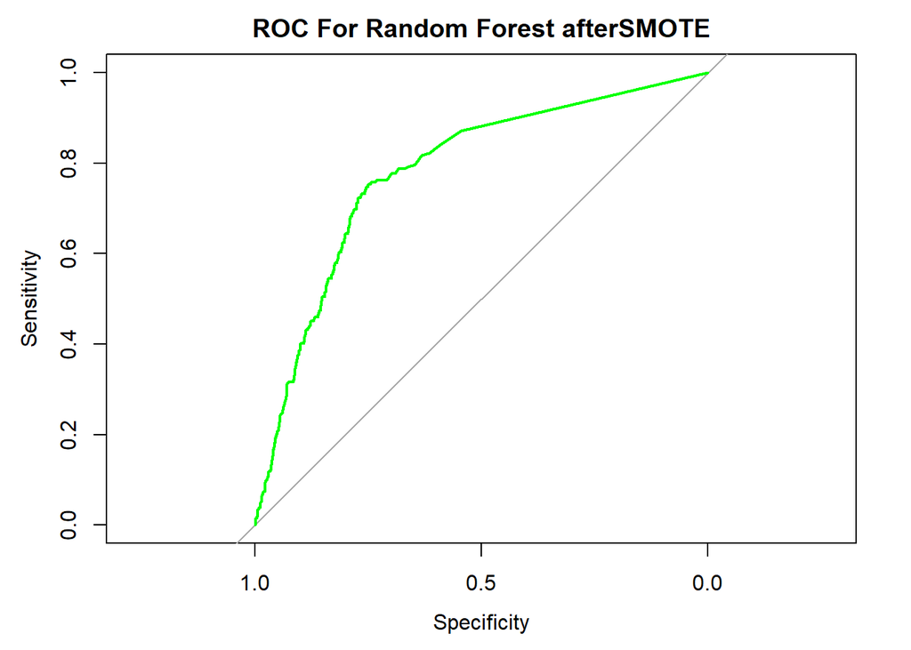

```r
ROC_rf_auc <- auc(ROC_rf)
plot(ROC_rf, col = "green", main = "ROC For Random Forest afterSMOTE")
```

According to the precision values, model3 is performing best in random forest.  
When comparing the ROC curve for beforeSMOTE and afterSMOTE models, AUC value is much higher for ROC afterSMOTE model.  
AUC for beforeSMOTE model: 0.65800  
AUC for afterSMOTE model: 0.77455

Although none of them is crossing the threshhold of 0.8. but afterSMOTE models are coming out to be very close to the threshhold and much better than beforeSMOTE models.

##Logistic Regression

### Logistic Regression on Original Dataset

```r
#before smote training
logitModel1_b <- glm(stroke~ ., data = beforeSMOTE, family = binomial())
logitModel2_b <- glm(stroke~ age + age:hypertension + age:heart_disease +age:avg_glucose_level, data = beforeSMOTE, family = binomial())
logitModel3_b <- glm(stroke~  age*heart_disease +age*glucoseGroup, data = beforeSMOTE, family = binomial())
logitModel4_b <- glm(stroke~ (age+heart_disease+ avg_glucose_level)^2 , data = beforeSMOTE, family = binomial())
logitModel5_b <- glm(stroke~ (age + glucoseGroup)^2 , data = beforeSMOTE, family = binomial())
logitModel6_b <- glm(stroke~ age+age:heart_disease+ age:avg_glucose_level , data = beforeSMOTE, family = binomial())
#selecting model for further analysis of code
logitModel_b <-logitModel3_b
summary(logitModel_b)
```

```
##
## Call:
## glm(formula = stroke ~ age * heart_disease + age * glucoseGroup,
##     family = binomial(), data = beforeSMOTE)
##
## Deviance Residuals:
##     Min       1Q   Median       3Q      Max
## -0.6257  -0.2257  -0.1188  -0.0585   3.6134
##
## Coefficients:
##                              Estimate Std. Error z value             Pr(>|z|)
## (Intercept)                 -6.535946   0.482903 -13.535 < 0.0000000000000002
## age                          0.055348   0.007058   7.842  0.00000000000000443
## heart_disease1               3.102264   0.847213   3.662             0.000251
## glucoseGroupNormal          -2.276732   0.584385  -3.896  0.00009781622827905
## glucoseGroupPrediabetes     -4.195387   1.353521  -3.100             0.001938
## age:heart_disease1          -0.034250   0.011920  -2.873             0.004061
## age:glucoseGroupNormal       0.023473   0.008508   2.759             0.005798
## age:glucoseGroupPrediabetes  0.053263   0.018921   2.815             0.004877
##
## (Intercept)                 ***
## age                         ***
## heart_disease1              ***
## glucoseGroupNormal          ***
## glucoseGroupPrediabetes     **
## age:heart_disease1          **
## age:glucoseGroupNormal      **
## age:glucoseGroupPrediabetes **
## ---
## Signif. codes:  0 '***' 0.001 '**' 0.01 '*' 0.05 '.' 0.1 ' ' 1
##
## (Dispersion parameter for binomial family taken to be 1)
##
##     Null deviance: 4203.1  on 20103  degrees of freedom
## Residual deviance: 3516.4  on 20096  degrees of freedom
## AIC: 3532.4
##
## Number of Fisher Scoring iterations: 8
```

```r
pR2(logitModel_b)
```

```
## fitting null model for pseudo-r2
```

```
##            llh        llhNull             G2       McFadden           r2ML
## -1758.21816783 -2101.56751184   686.69868802     0.16337774     0.03358054
##           r2CU
##     0.17799386
```

```r
AIC(logitModel_b)
```

```
## [1] 3532.436
```

### Logistic Regression on Upsampled Dataset

```r
#after smote training
logitModel1_a <- glm(stroke~ ., data = afterSMOTE, family = binomial())
logitModel2_a <- glm(stroke~ age + age:hypertension + age:heart_disease +age:avg_glucose_level, data = afterSMOTE, family = binomial())
logitModel3_a <- glm(stroke~ age*heart_disease +age*glucoseGroup, data = afterSMOTE, family = binomial())
logitModel4_a <- glm(stroke~ (age+heart_disease+ avg_glucose_level)^2, data = afterSMOTE, family = binomial())
logitModel5_a <- glm(stroke~ (age + glucoseGroup)^2, data = afterSMOTE, family = binomial())
logitModel6_a <- glm(stroke~ age+age:heart_disease+ age:avg_glucose_level , data = afterSMOTE, family = binomial())
#selecting model for further analysis of code
logitModel_a <- logitModel3_a
summary(logitModel_a)
```

```
##
## Call:
## glm(formula = stroke ~ age * heart_disease + age * glucoseGroup,
##     family = binomial(), data = afterSMOTE)
##
## Deviance Residuals:
##     Min       1Q   Median       3Q      Max
## -2.5244  -0.5292  -0.1493   0.5895   3.1362
##
## Coefficients:
##                              Estimate Std. Error z value             Pr(>|z|)
## (Intercept)                 -5.898599   0.201100 -29.332 < 0.0000000000000002
## age                          0.088962   0.003010  29.551 < 0.0000000000000002
## heart_disease1               6.264790   0.287160  21.816 < 0.0000000000000002
## glucoseGroupNormal          -2.055081   0.240701  -8.538 < 0.0000000000000002
## glucoseGroupPrediabetes     -1.665271   0.349928  -4.759       0.000001946488
## age:heart_disease1          -0.067617   0.004208 -16.068 < 0.0000000000000002
## age:glucoseGroupNormal       0.015972   0.003576   4.466       0.000007952461
## age:glucoseGroupPrediabetes  0.032840   0.005356   6.131       0.000000000874
##
## (Intercept)                 ***
## age                         ***
## heart_disease1              ***
## glucoseGroupNormal          ***
## glucoseGroupPrediabetes     ***
## age:heart_disease1          ***
## age:glucoseGroupNormal      ***
## age:glucoseGroupPrediabetes ***
## ---
## Signif. codes:  0 '***' 0.001 '**' 0.01 '*' 0.05 '.' 0.1 ' ' 1
##
## (Dispersion parameter for binomial family taken to be 1)
##
##     Null deviance: 34246  on 26595  degrees of freedom
## Residual deviance: 19959  on 26588  degrees of freedom
## AIC: 19975
##
## Number of Fisher Scoring iterations: 6
```

```r
pR2(logitModel_a)
```

```
## fitting null model for pseudo-r2
```

```
##            llh        llhNull             G2       McFadden           r2ML
##  -9979.6747497 -17123.0961720  14286.8428447      0.4171805      0.4156062
##           r2CU
##      0.5739782
```

```r
AIC(logitModel_a)
```

```
## [1] 19975.35
```

Here with the upsampled datset the psuedo R2 value has increased a lot which is because with more data points of 1, a lot more variance in y is explained by the variables now.